# Temperature, Salinity, and Secchi analyses

Sam Bashevkin

August 01, 2023

# Load packages and functions

```r
require(conflicted)
require(dplyr)
require(ggplot2)
require(patchwork)
require(knitr)
require(car)
require(multcomp)
require(emmeans)
require(stringr)
require(readr)
require(tidyr)
library(kableExtra)
library(here)

source(here("src/analysis/global_analysis_functions.R"))

conflict_prefer("filter", "dplyr")
conflict_prefer("select", "dplyr")
```

# Load data

```r
# Import long-term average data for the water quality measurements
wq_data <- read_rds(here("data/processed/wq/lt_avg_wq_meas.rds"))

# Prepare data for analyses
wq_data_c <- wq_data %>%
  mutate(
    # Change region names to "South-Central Delta" and "North Delta"
    Region = case_when(
      Region == "SouthCentral" ~ "South-Central Delta",
      Region == "North" ~ "North Delta",
      TRUE ~ Region
    ),
    Region = factor(
      Region,
      levels = c("Suisun Marsh", "Suisun Bay", "Confluence", "South-Central Delta", "North Delta")
    ),
    Season = factor(Season, levels = c("Winter", "Spring", "Summer", "Fall")),
    Year_fac = factor(YearAdj),
    Drought = factor(Drought, levels = c("D", "N", "W")),
    YearAdj_s = (YearAdj - mean(YearAdj) / sd(YearAdj)),
    across(c(Secchi, Salinity), list(l = log))
  )
```

# Plots

Note that each facet has a different y-axis scale

## By year

### Temperature

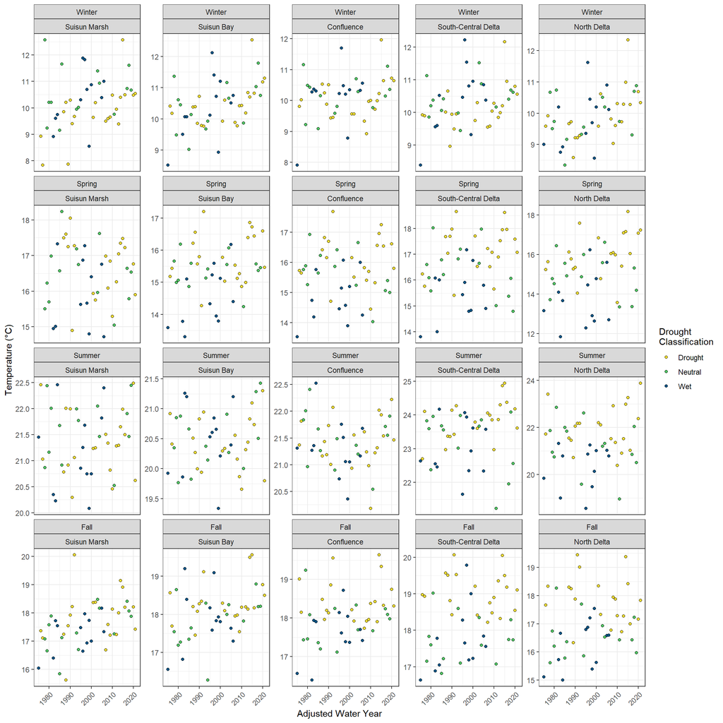

```r
ggplot(wq_data_c, aes(x=YearAdj, y=Temperature, fill=Drought))+
  geom_point(shape=21, color="black")+
  facet_wrap(Season~Region, scales="free_y")+
  color_pal_drought()+
  ylab("Temperature (°C)")+
  xlab("Adjusted Water Year") +
  theme_bw()+
  theme(axis.text.x=element_text(angle=45, hjust=1))
```

### Salinity

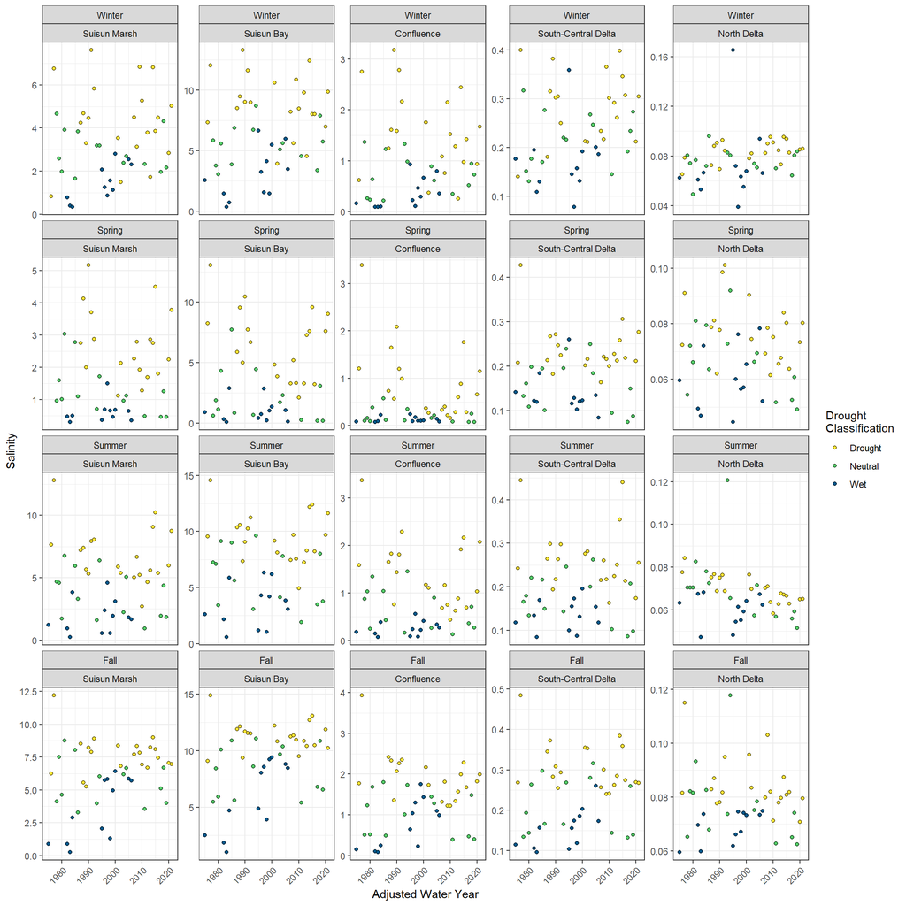

```r
ggplot(wq_data_c, aes(x=YearAdj, y=Salinity, fill=Drought))+
  geom_point(shape=21, color="black")+
  facet_wrap(Season~Region, scales="free_y")+
  color_pal_drought()+
  ylab("Salinity")+
  xlab("Adjusted Water Year") +
  theme_bw()+
  theme(axis.text.x=element_text(angle=45, hjust=1))
```

### Secchi

Secchi is also more regionally than seasonally variable

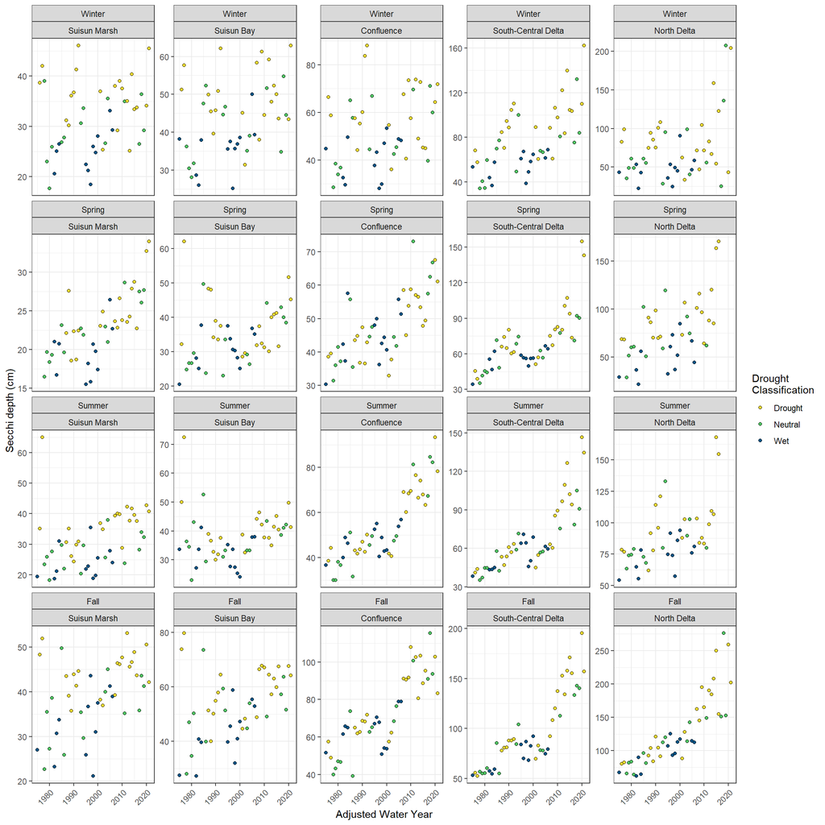

```r
plt_se_point <- ggplot(wq_data_c, aes(x=YearAdj, y=Secchi, fill=Drought))+
  geom_point(shape=21, color="black")+
  facet_wrap(Season~Region, scales="free_y")+
  color_pal_drought()+
  ylab("Secchi depth (cm)")+
  xlab("Adjusted Water Year") +
  theme_bw()+
  theme(axis.text.x=element_text(angle=45, hjust=1))

plt_se_point
```

Save Secchi depth figure for Supplemental Info.

```r
ggsave(
  here("results/figures/secchi_point_region_season.jpg"),
  plot = plt_se_point,
  width = 11,
  height = 9,
  units = "in",
  dpi = 300
)
```

# By Drought index

### Temperature

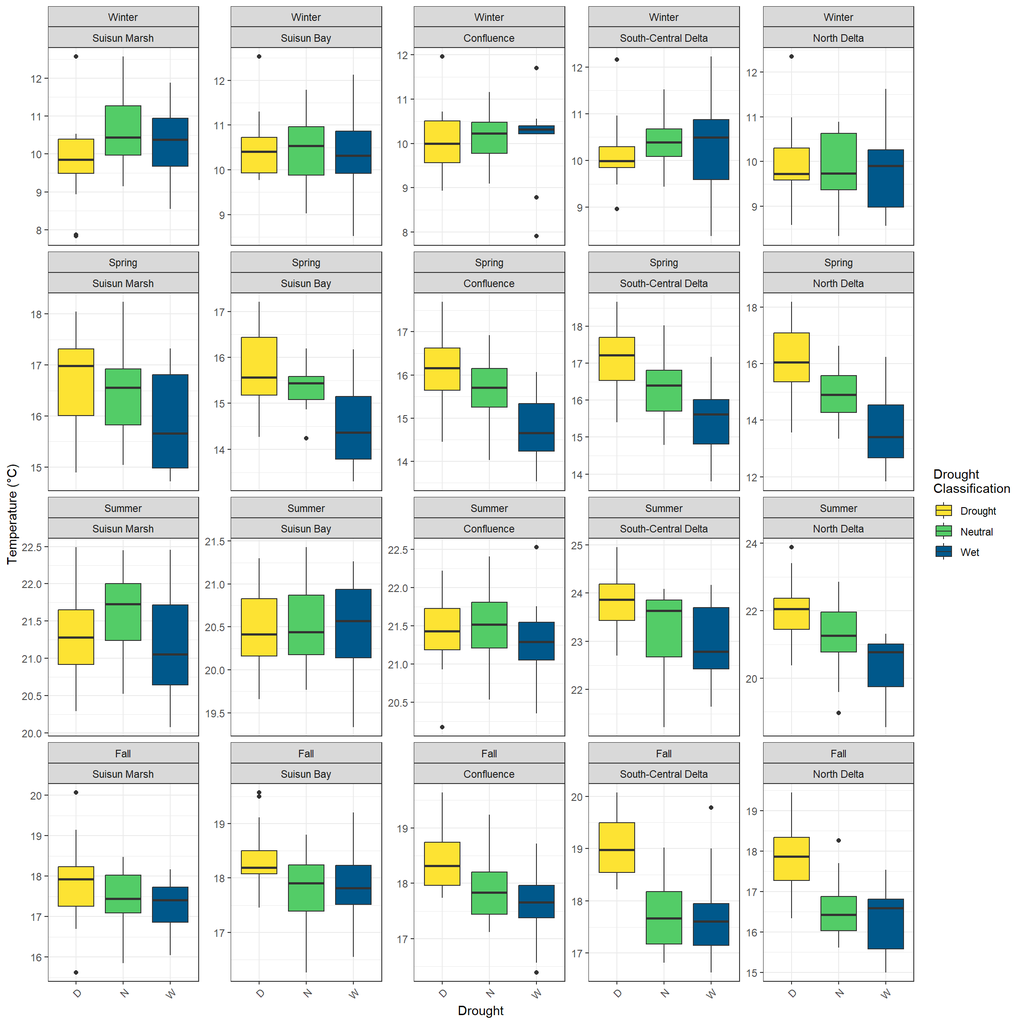

```r
ggplot(wq_data_c, aes(x=Drought, y=Temperature, fill=Drought))+
  geom_boxplot()+
  facet_wrap(Season~Region, scales="free_y")+
  color_pal_drought()+
  ylab("Temperature (°C)")+
  theme_bw()+
  theme(axis.text.x=element_text(angle=45, hjust=1))
```

### Salinity

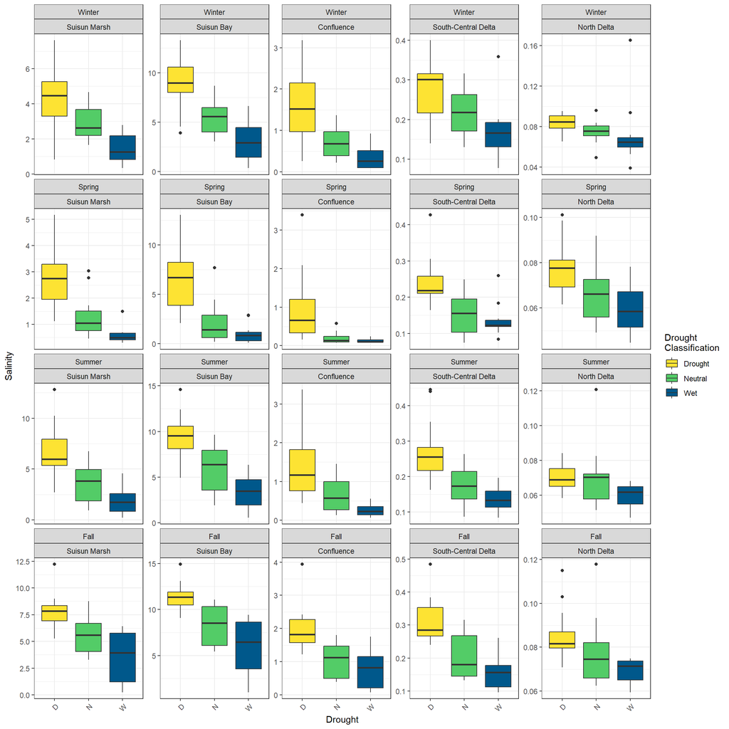

```r
ggplot(wq_data_c, aes(x=Drought, y=Salinity, fill=Drought))+
  geom_boxplot()+
  facet_wrap(Season~Region, scales="free_y")+
  color_pal_drought()+
  ylab("Salinity")+
  theme_bw()+
  theme(axis.text.x=element_text(angle=45, hjust=1))
```

### Secchi

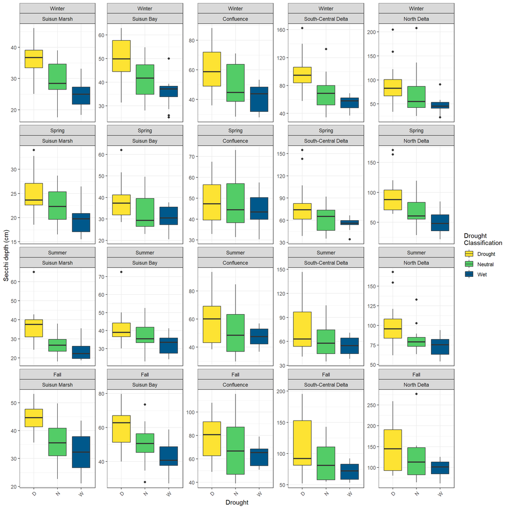

```r
ggplot(wq_data_c, aes(x=Drought, y=Secchi, fill=Drought))+
  geom_boxplot()+
  facet_wrap(Season~Region, scales="free_y")+
  color_pal_drought()+
  ylab("Secchi depth (cm)")+
  theme_bw()+
  theme(axis.text.x=element_text(angle=45, hjust=1))
```

# Analyses

## Temperature

```r
m_t<-aov(Temperature ~ (Drought + Season + Region)^2, data=wq_data_c)
```

### Check assumptions:

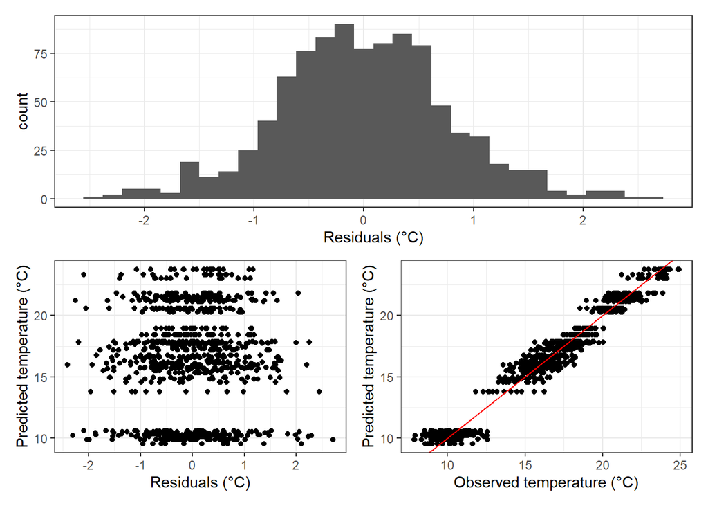

```r
model_plotter(m_t, wq_data_c, "Temperature")
```

### Check results

```r
m_t_Anova<-Anova(m_t, type=3, contrasts=list(topic=contr.sum, sys=contr.sum))
m_t_Anova
```

```
## Anova Table (Type III tests)
##
## Response: Temperature
##                 Sum Sq  Df   F value    Pr(>F)
## (Intercept)    3033.95   1 4799.0185 < 2.2e-16 ***
## Drought          10.61   2    8.3885 0.0002457 ***
## Season         2582.95   3 1361.8787 < 2.2e-16 ***
## Region            5.43   4    2.1482 0.0730497 .
## Drought:Season   60.77   6   16.0197 < 2.2e-16 ***
## Drought:Region   31.80   8    6.2876 6.062e-08 ***
## Season:Region   178.04  12   23.4679 < 2.2e-16 ***
## Residuals       568.98 900
## ---
## Signif. codes:  0 '***' 0.001 '**' 0.01 '*' 0.05 '.' 0.1 ' ' 1
```

### Partial R<sup>2</sup>

How much variability is explained by the Drought index?

```r
partial.r2(m_t_Anova)
```

```
## [1] 0.1534957
```

### Post-hoc test

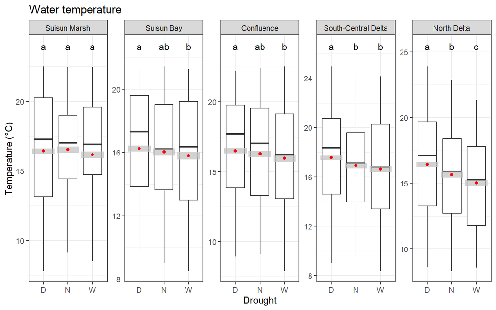

```r
m_t_contrasts_r <- pub_figure_plotter(df_data=wq_data_c, param=Temperature, y_label="Temperature (°C)",
                                      fct_grp=Region, model=m_t, plt_title = "Water temperature")
```

```r
m_t_contrasts_r$diffs
```

```
## # A tibble: 5 × 4
##   Region                  D     W difference
##   <fct>               <dbl> <dbl>      <dbl>
## 1 Suisun Marsh         16.4  16.2      0.260
## 2 Suisun Bay           16.3  15.8      0.448
## 3 Confluence           16.5  16.0      0.540
## 4 South-Central Delta  17.6  16.6      0.902
## 5 North Delta          16.4  15.0      1.42
```

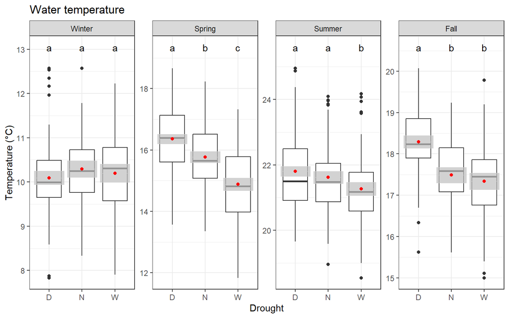

```r
m_t_contrasts_s <- pub_figure_plotter(df_data=wq_data_c, param=Temperature, y_label="Temperature (°C)",
                                      fct_grp=Season, model=m_t, plt_title = "Water temperature")
```

```r
m_t_contrasts_s$diffs
```

```
## # A tibble: 4 × 4
##   Season     D     W difference
##   <fct>  <dbl> <dbl>      <dbl>
## 1 Winter  10.1  10.2     -0.106
## 2 Spring  16.4  14.9      1.47
## 3 Summer  21.8  21.3      0.536
## 4 Fall    18.3  17.3      0.952
```

## Salinity

Salinity data had to be log transformed to fit the assumption of normality

```r
m_sa<-aov(Salinity_l ~ (Drought + Season + Region)^2, data=wq_data_c)
```

### Check assumptions:

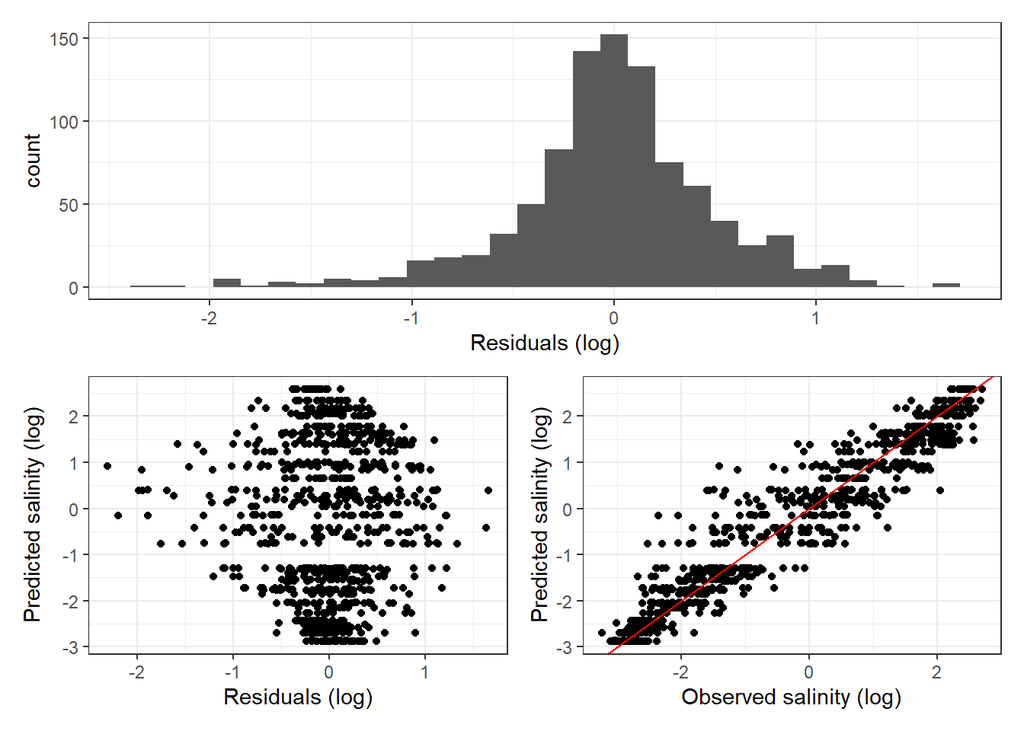

```r
model_plotter(m_sa, wq_data_c, "Salinity_l")
```

### Check results

```r
m_sa_Anova<-Anova(m_sa, type=3, contrasts=list(topic=contr.sum, sys=contr.sum))
m_sa_Anova
```

```
## Anova Table (Type III tests)
##
## Response: Salinity_l
##                Sum Sq  Df  F value    Pr(>F)
## (Intercept)     61.12   1 238.5221 < 2.2e-16 ***
## Drought         30.41   2  59.3430 < 2.2e-16 ***
## Season          24.91   3  32.3992 < 2.2e-16 ***
## Region         536.06   4 523.0062 < 2.2e-16 ***
## Drought:Season   8.41   6   5.4731 1.414e-05 ***
## Drought:Region  46.45   8  22.6613 < 2.2e-16 ***
## Season:Region   45.49  12  14.7934 < 2.2e-16 ***
## Residuals      230.62 900
## ---
## Signif. codes:  0 '***' 0.001 '**' 0.01 '*' 0.05 '.' 0.1 ' ' 1
```

### Partial R<sup>2</sup>

How much variability is explained by the Drought index?

```r
partial.r2(m_sa_Anova)
```

```
## [1] 0.2699633
```

### Post-hoc test

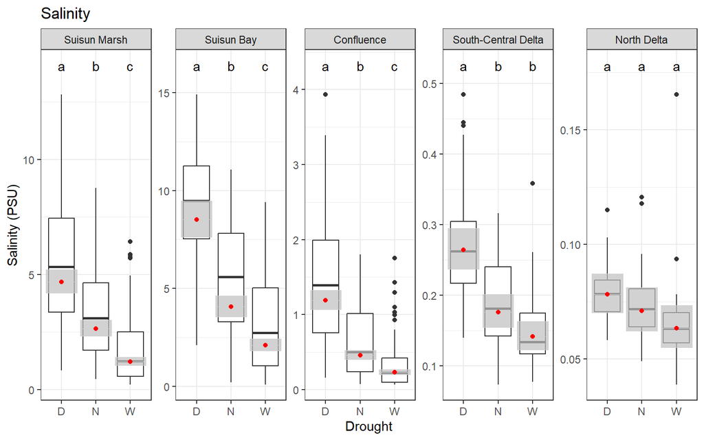

```r
m_sa_contrasts_r <- pub_figure_plotter(df_data=wq_data_c, param=Salinity, y_label="Salinity (PSU)",
                                       fct_grp=Region, model=m_sa, log_trans = TRUE, plt_title = "Salinity")
```

```r
m_sa_contrasts_r$diffs
```

```
## # A tibble: 5 × 4
##   Region                   D      W difference
##   <fct>                <dbl>  <dbl>      <dbl>
## 1 Suisun Marsh        4.68   1.22       3.46
## 2 Suisun Bay          8.51   2.10       6.41
## 3 Confluence          1.19   0.234      0.956
## 4 South-Central Delta 0.264  0.142      0.123
## 5 North Delta         0.0782 0.0636     0.0147
```

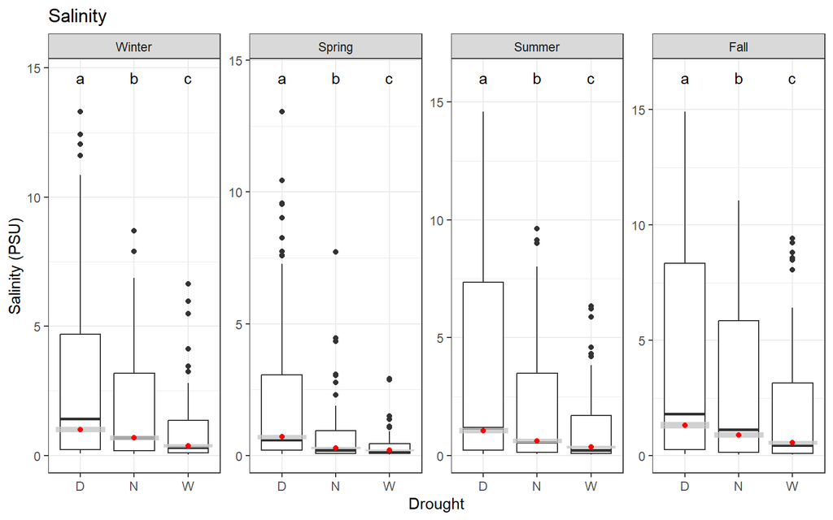

```r
m_sa_contrasts_s <- pub_figure_plotter(df_data=wq_data_c, param=Salinity, y_label="Salinity (PSU)",
                                       fct_grp=Season, model=m_sa, log_trans = TRUE, plt_title = "Salinity")
```

```r
m_sa_contrasts_s$diffs
```

```
## # A tibble: 4 × 4
##   Season     D     W difference
##   <fct>  <dbl> <dbl>      <dbl>
## 1 Winter 0.999 0.375      0.623
## 2 Spring 0.706 0.199      0.507
## 3 Summer 1.06  0.362      0.694
## 4 Fall   1.32  0.569      0.753
```

## Secchi Depth

Secchi depth had to be log-transformed to comply with the assumption of normality

```r
m_se<-aov(Secchi_l ~ (Drought + Season + Region)^2, data=wq_data_c)
```

### Check assumptions:

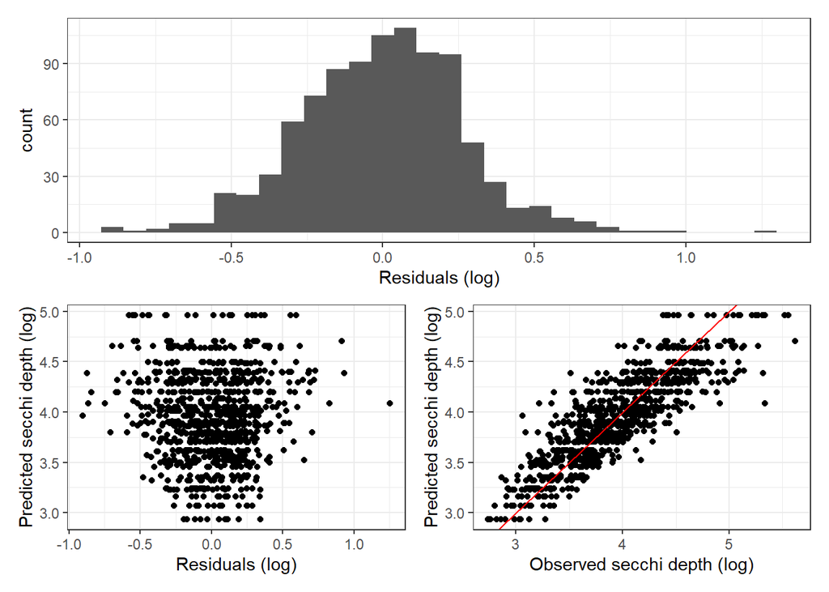

```r
model_plotter(m_se, wq_data_c, "Secchi_l")
```

### Check results

```r
m_se_Anova<-Anova(m_se, type=3, contrasts=list(topic=contr.sum, sys=contr.sum))
m_se_Anova
```

```
## Anova Table (Type III tests)
##
## Response: Secchi_l
##                Sum Sq  Df   F value    Pr(>F)
## (Intercept)    405.41   1 5467.3158 < 2.2e-16 ***
## Drought          3.90   2   26.3122 7.904e-12 ***
## Season           5.64   3   25.3312 9.897e-16 ***
## Region          18.56   4   62.5914 < 2.2e-16 ***
## Drought:Season   0.58   6    1.2997   0.25454
## Drought:Region   1.41   8    2.3745   0.01563 *
## Season:Region    5.32  12    5.9819 4.112e-10 ***
## Residuals       65.99 890
## ---
## Signif. codes:  0 '***' 0.001 '**' 0.01 '*' 0.05 '.' 0.1 ' ' 1
```

### Partial R<sup>2</sup>

How much variability is explained by the Drought index?

```r
partial.r2(m_se_Anova)
```

```
## [1] 0.08192418
```

### Post-hoc test

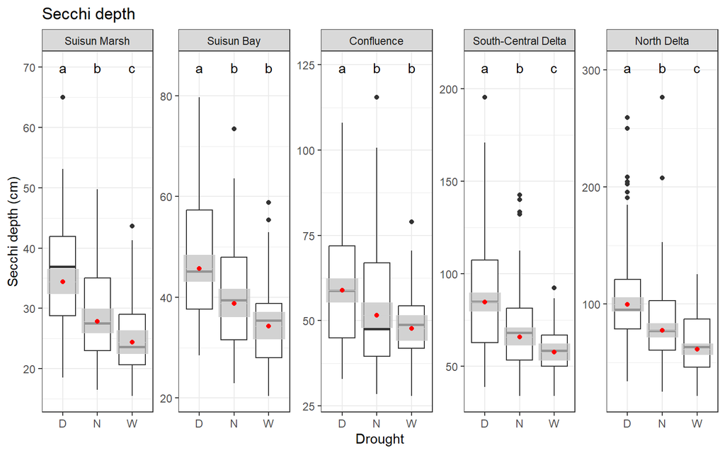

```r
m_se_contrasts_r <- pub_figure_plotter(df_data=wq_data_c, param=Secchi, y_label="Secchi depth (cm)",
                                       fct_grp=Region, model=m_se, log_trans = TRUE, plt_title = "Secchi depth")
```

```r
m_se_contrasts_r$diffs
```

```
## # A tibble: 5 × 4
##   Region                  D     W difference
##   <fct>               <dbl> <dbl>      <dbl>
## 1 Suisun Marsh         34.4  24.4       10.0
## 2 Suisun Bay           45.7  34.3       11.4
## 3 Confluence           58.8  47.8       11.1
## 4 South-Central Delta  84.9  57.8       27.1
## 5 North Delta          99.5  61.1       38.4
```

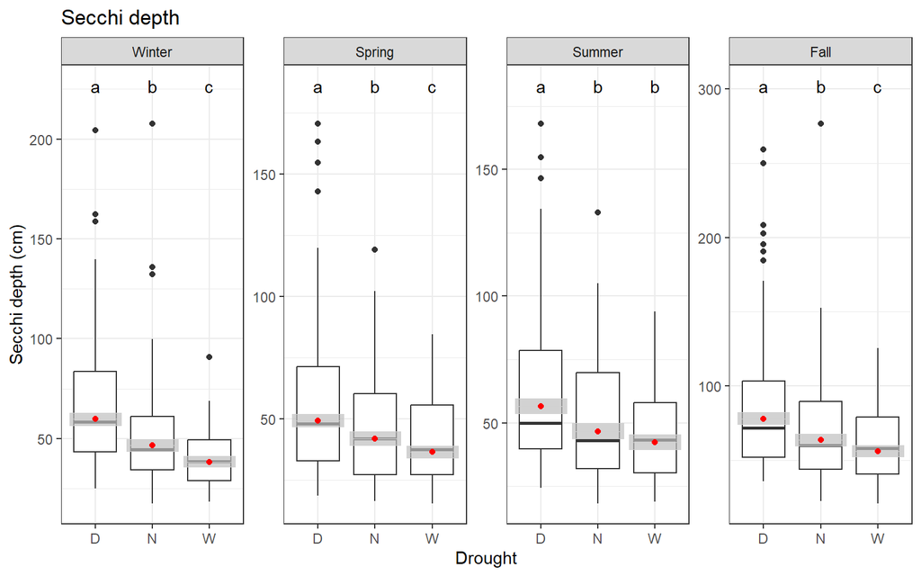

```r
m_se_contrasts_s <- pub_figure_plotter(df_data=wq_data_c, param=Secchi, y_label="Secchi depth (cm)",
                                       fct_grp=Season, model=m_se, log_trans = TRUE, plt_title = "Secchi depth")
```

```r
m_se_contrasts_s$diffs
```

```
## # A tibble: 4 × 4
##   Season     D     W difference
##   <fct>  <dbl> <dbl>      <dbl>
## 1 Winter  59.7  38.3       21.4
## 2 Spring  49.4  36.4       13.0
## 3 Summer  56.6  42.3       14.3
## 4 Fall    78.1  56.0       22.1
```

## Secchi Depth with annual trend

Secchi depth had to be log-transformed to comply with the assumption of normality

```r
m_se2<-aov(Secchi_l ~ (Drought + Season + Region)^2 + YearAdj*Season*Region, data=wq_data_c)
```

### Check assumptions:

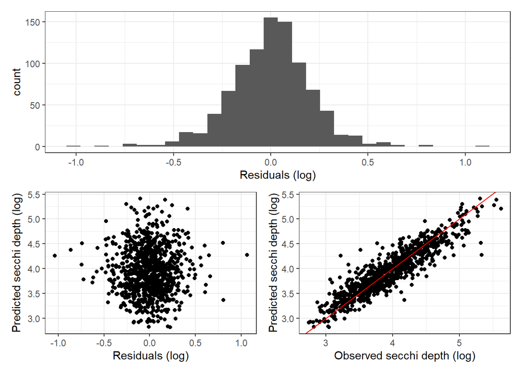

```r
model_plotter(m_se2, wq_data_c, "Secchi_l")
```

### Check results

```r
m_se2_Anova<-Anova(m_se2, type=3, contrasts=list(topic=contr.sum, sys=contr.sum))
m_se2_Anova
```

```
## Anova Table (Type III tests)
##
## Response: Secchi_l
##                       Sum Sq  Df F value    Pr(>F)
## (Intercept)            0.001   1  0.0286 0.8658303
## Drought                3.551   2 38.4174 < 2.2e-16 ***
## Season                 0.171   3  1.2308 0.2973327
## Region                 0.843   4  4.5615 0.0011916 **
## YearAdj                0.015   1  0.3338 0.5635566
## Drought:Season         1.001   6  3.6109 0.0015231 **
## Drought:Region         1.272   8  3.4401 0.0006562 ***
## Season:Region          1.207  12  2.1758 0.0111877 *
## Season:YearAdj         0.163   3  1.1742 0.3184950
## Region:YearAdj         0.895   4  4.8438 0.0007229 ***
## Season:Region:YearAdj  1.213  12  2.1870 0.0107196 *
## Residuals             40.203 870
## ---
## Signif. codes:  0 '***' 0.001 '**' 0.01 '*' 0.05 '.' 0.1 ' ' 1
```

### Partial R<sup>2</sup>

How much variability is explained by the Drought index?

```r
partial.r2(m_se2_Anova)
```

```
## [1] 0.126524
```

### Post-hoc test

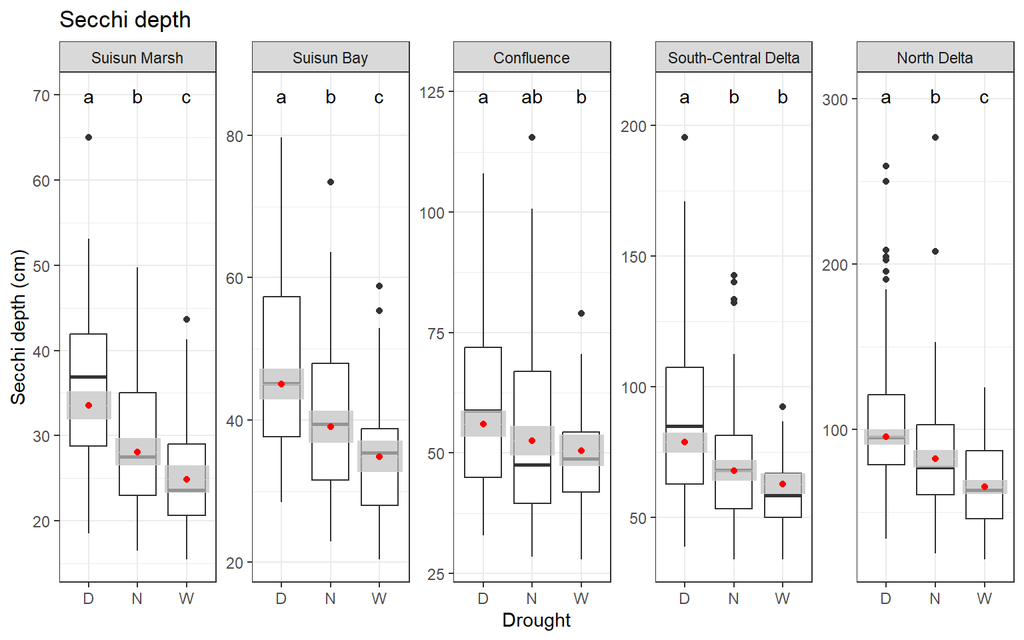

```r
m_se2_contrasts_r <- pub_figure_plotter(df_data=wq_data_c, param=Secchi, y_label="Secchi depth (cm)",
                                        fct_grp=Region, model=m_se2, log_trans = TRUE, plt_title = "Secchi depth")
```

```r
m_se2_contrasts_r$diffs
```

```
## # A tibble: 5 × 4
##   Region                  D     W difference
##   <fct>               <dbl> <dbl>      <dbl>
## 1 Suisun Marsh         33.6  24.8       8.72
## 2 Suisun Bay           45.1  34.9      10.2
## 3 Confluence           56.0  50.5       5.55
## 4 South-Central Delta  78.8  62.9      15.9
## 5 North Delta          95.3  65.2      30.1
```

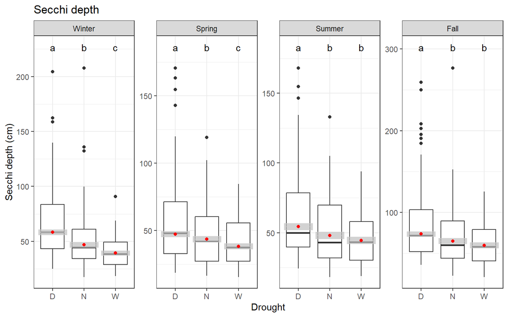

```r
m_se2_contrasts_s <- pub_figure_plotter(df_data=wq_data_c, param=Secchi, y_label="Secchi depth (cm)",
                                        fct_grp=Season, model=m_se2, log_trans = TRUE, plt_title = "Secchi depth")
```

```r
m_se2_contrasts_s$diffs
```

```
## # A tibble: 4 × 4
##   Season     D     W difference
##   <fct>  <dbl> <dbl>      <dbl>
## 1 Winter  58.3  39.4      18.9
## 2 Spring  47.4  38.3       9.12
## 3 Summer  54.3  44.5       9.86
## 4 Fall    73.7  59.8      13.9
```

## Save all model outputs

```r
# Define file paths for output and figures for the manuscript
fp_output <- here("results/tables")
fp_plots <- here("results/figures")
```

### Anovas

```r
anovas <-
  bind_rows(
    mutate(as_tibble(m_t_Anova, rownames = "Parameter"), Model="Temperature"),
    mutate(as_tibble(m_sa_Anova, rownames = "Parameter"), Model="Salinity"),
    mutate(as_tibble(m_se2_Anova, rownames = "Parameter"), Model="Secchi depth")
  ) %>%
  mutate(
    `Pr(>F)`=if_else(
      `Pr(>F)`<0.001,
      "< 0.001",
      as.character(formatC(signif(`Pr(>F)`, 4), digits = 4, format = "fg", flag = "#"))
    ),
    across(c(`Sum Sq`, `F value`), ~formatC(signif(.x, 4), digits = 4, format = "fg", flag = "#"))
  ) %>%
  relocate(Model)

kbl(anovas) %>% kable_styling(fixed_thead = TRUE)
```

Model

Parameter

Sum Sq

Df

F value

Pr(>F)

Temperature

(Intercept)

1

< 0.001

Temperature

Drought

10.61

2

8.389

< 0.001

Temperature

Season

3

< 0.001

Temperature

Region

5.432

4

2.148

0.07305

Temperature

Drought:Season

60.77

6

16.02

< 0.001

Temperature

Drought:Region

31.80

8

6.288

< 0.001

Temperature

Season:Region

178.0

12

23.47

< 0.001

Temperature

Residuals

569.0

900

NA

NA

Salinity

(Intercept)

61.12

1

238.5

< 0.001

Salinity

Drought

30.41

2

59.34

< 0.001

Salinity

Season

24.91

3

32.40

< 0.001

Salinity

Region

536.1

4

523.0

< 0.001

Salinity

Drought:Season

8.414

6

5.473

< 0.001

Salinity

Drought:Region

46.45

8

22.66

< 0.001

Salinity

Season:Region

45.49

12

14.79

< 0.001

Salinity

Residuals

230.6

900

NA

NA

Secchi depth

(Intercept)

0.001320

1

0.02856

0.8658

Secchi depth

Drought

3.551

2

38.42

< 0.001

Secchi depth

Season

0.1706

3

1.231

0.2973

Secchi depth

Region

0.8432

4

4.561

0.001192

Secchi depth

YearAdj

0.01543

1

0.3338

0.5636

Secchi depth

Drought:Season

1.001

6

3.611

0.001523

Secchi depth

Drought:Region

1.272

8

3.440

< 0.001

Secchi depth

Season:Region

1.207

12

2.176

0.01119

Secchi depth

Season:YearAdj

0.1628

3

1.174

0.3185

Secchi depth

Region:YearAdj

0.8953

4

4.844

< 0.001

Secchi depth

Season:Region:YearAdj

1.213

12

2.187

0.01072

Secchi depth

Residuals

40.20

870

NA

NA

```r
# Excel is the worst, I had to add letters to these numbers so it wouldn't re-round them
anovas %>%
  mutate(
    across(
      c(`Sum Sq`, `F value`, `Pr(>F)`),
      ~paste0(ifelse(str_detect(.x, fixed("NA")) | is.na(.x), "", .x), "ZZZ")
    )
  ) %>%
  write_csv(file.path(fp_output, "TempSalSecchi_anovas.csv"))
```

### Post-hoc tests

```r
tukeys <-
  bind_rows(
    mutate(as_tibble(m_t_contrasts_r$contrasts), Model="Temperature", `Contrast type`="region"),
    mutate(as_tibble(m_t_contrasts_s$contrasts), Model="Temperature", `Contrast type`="season"),
    mutate(as_tibble(m_sa_contrasts_r$contrasts), Model="Salinity", `Contrast type`="region"),
    mutate(as_tibble(m_sa_contrasts_s$contrasts), Model="Salinity", `Contrast type`="season"),
    mutate(as_tibble(m_se2_contrasts_r$contrasts), Model="Secchi depth", `Contrast type`="region"),
    mutate(as_tibble(m_se2_contrasts_s$contrasts), Model="Secchi depth", `Contrast type`="season")
  ) %>%
  rename(
    `p-value`=p.value,
    `t-ratio`=t.ratio
  ) %>%
  mutate(
    `p-value`=if_else(
      `p-value`<0.001,
      "< 0.001",
      as.character(formatC(signif(`p-value`, 4), digits=4, format="fg", flag="#"))
    ),
    Group=if_else(is.na(Region), as.character(Season), as.character(Region)),
    across(c(estimate, SE, `t-ratio`), ~formatC(signif(.x, 4), digits=4, format="fg", flag="#"))
  ) %>%
  select(
    Model,
    `Contrast type`,
    Group,
    Contrast=contrast,
    Estimate=estimate,
    SE,
    DF=df,
    `t-ratio`,
    `p-value`
  )

kbl(tukeys) %>% kable_styling(fixed_thead = TRUE)
```

| Model | Contrast type | Group | Contrast | Estimate | SE | DF | t-ratio | p-value |
| --- | --- | --- | --- | --- | --- | --- | --- | --- |
| Temperature | region | Suisun Marsh | D - N | -0.09981 | 0.1379 | 900 | -0.7240 | 0.7493 |
| Temperature | region | Suisun Marsh | D - W | 0.2605 | 0.1465 | 900 | 1.778 | 0.1776 |
| Temperature | region | Suisun Marsh | N - W | 0.3603 | 0.1583 | 900 | 2.277 | 0.05962 |
| Temperature | region | Suisun Bay | D - N | 0.2205 | 0.1372 | 900 | 1.608 | 0.2429 |
| Temperature | region | Suisun Bay | D - W | 0.4481 | 0.1439 | 900 | 3.114 | 0.005395 |
| Temperature | region | Suisun Bay | N - W | 0.2275 | 0.1564 | 900 | 1.455 | 0.3134 |
| Temperature | region | Confluence | D - N | 0.2060 | 0.1372 | 900 | 1.501 | 0.2907 |
| Temperature | region | Confluence | D - W | 0.5403 | 0.1439 | 900 | 3.756 | < 0.001 |
| Temperature | region | Confluence | N - W | 0.3343 | 0.1564 | 900 | 2.138 | 0.08292 |
| Temperature | region | South-Central Delta | D - N | 0.6159 | 0.1372 | 900 | 4.490 | < 0.001 |
| Temperature | region | South-Central Delta | D - W | 0.9019 | 0.1439 | 900 | 6.269 | < 0.001 |
| Temperature | region | South-Central Delta | N - W | 0.2860 | 0.1564 | 900 | 1.829 | 0.1608 |
| Temperature | region | North Delta | D - N | 0.7882 | 0.1372 | 900 | 5.746 | < 0.001 |
| Temperature | region | North Delta | D - W | 1.421 | 0.1439 | 900 | 9.876 | < 0.001 |
| Temperature | region | North Delta | N - W | 0.6326 | 0.1564 | 900 | 4.045 | < 0.001 |
| Temperature | season | Winter | D - N | -0.1974 | 0.1227 | 900 | -1.609 | 0.2424 |
| Temperature | season | Winter | D - W | -0.1055 | 0.1294 | 900 | -0.8155 | 0.6935 |
| Temperature | season | Winter | N - W | 0.09187 | 0.1405 | 900 | 0.6537 | 0.7903 |
| Temperature | season | Spring | D - N | 0.5911 | 0.1232 | 900 | 4.798 | < 0.001 |
| Temperature | season | Spring | D - W | 1.475 | 0.1298 | 900 | 11.36 | < 0.001 |
| Temperature | season | Spring | N - W | 0.8836 | 0.1405 | 900 | 6.287 | < 0.001 |
| Temperature | season | Summer | D - N | 0.1863 | 0.1227 | 900 | 1.518 | 0.2829 |
| Temperature | season | Summer | D - W | 0.5365 | 0.1287 | 900 | 4.169 | < 0.001 |
| Temperature | season | Summer | N - W | 0.3502 | 0.1399 | 900 | 2.504 | 0.03334 |
| Temperature | season | Fall | D - N | 0.8047 | 0.1227 | 900 | 6.559 | < 0.001 |
| Temperature | season | Fall | D - W | 0.9516 | 0.1287 | 900 | 7.395 | < 0.001 |
| Temperature | season | Fall | N - W | 0.1469 | 0.1399 | 900 | 1.050 | 0.5453 |
| Salinity | region | Suisun Marsh | D - N | 0.5693 | 0.08777 | 900 | 6.487 | < 0.001 |
| Salinity | region | Suisun Marsh | D - W | 1.342 | 0.09327 | 900 | 14.39 | < 0.001 |
| Salinity | region | Suisun Marsh | N - W | 0.7730 | 0.1007 | 900 | 7.672 | < 0.001 |

[output cut: 51 more lines]

```r
# Excel is the worst, I had to add letters to these numbers so it wouldn't re-round them
tukeys %>%
  mutate(
    across(
      c(Estimate, SE, `t-ratio`, `p-value`),
      ~paste0(ifelse(str_detect(.x, fixed("NA")) | is.na(.x), "", .x), "ZZZ")
    )
  ) %>%
  write_csv(file.path(fp_output, "TempSalSecchi_tukeys.csv"))
```

### Manuscript Figures

Combine all figures of model results for the water quality parameters into larger figures for the manuscript, one for the regional analyses and one for the seasonal analyses.

```r
# Region plots
plt_wq_region <- comb_pub_figs(list(m_t_contrasts_r$plt, m_sa_contrasts_r$plt, m_se2_contrasts_r$plt))

ggsave(
  file.path(fp_plots, "water_quality_region.jpg"),
  plot = plt_wq_region,
  width = 8,
  height = 9,
  units = "in",
  dpi = 300
)

# Season plots
plt_wq_season <- comb_pub_figs(list(m_t_contrasts_s$plt, m_sa_contrasts_s$plt, m_se2_contrasts_s$plt))

ggsave(
  file.path(fp_plots, "water_quality_season.jpg"),
  plot = plt_wq_season,
  width = 8,
  height = 9,
  units = "in",
  dpi = 300
)
```